# Spine_missing_values_prediction

```python
import pandas as pd
import numpy as np
import matplotlib.pyplot as plt
import seaborn as sns
%matplotlib inline
```

### Lower Back Pain

> About 80 percent of adults experience low back pain at some point in their lifetimes. It is the most common cause of job-related disability and a leading contributor to missed work days. In a large survey, more than a quarter of adults reported experiencing low back pain during the past 3 months [[1]](https://www.ninds.nih.gov/DISORDERS/PATIENT-CAREGIVER-EDUCATION/FACT-SHEETS/LOW-BACK-PAIN-FACT-SHEET)

It can be caused by a variety of problems with any parts of the complex, interconnected network of spinal muscles, nerves, bones, discs or tendons in the lumbar spine.

While lower back pain is extremely common, the symptoms and severity of lower back pain vary greatly. A simple lower back muscle strain might be excruciating enough to necessitate an emergency room visit, while a degenerating disc might cause only mild, intermittent discomfort.

Typical sources of low back pain include:

- The large nerve roots in the low back that go to the legs may be irritated.
- The smaller nerves that supply the low back may be irritated.
- The large paired lower back muscles (erector spinae) may be strained.
- The bones, ligaments or joints may be damaged.
- An intervertebral disc may be degenerating.

**Read the file:**

```python
data = pd.read_csv('lower_back_pain_with_extra_pain.csv', header=0)
```

```python
data.head(15)
```

|  | Col1 | Col2 | Col3 | Col4 | Col5 | Col6 | Col7 | Col8 | Col9 | Col10 | Col11 | Col12 | Class_att | Unnamed: 13 |
| --- | --- | --- | --- | --- | --- | --- | --- | --- | --- | --- | --- | --- | --- | --- |
| 0 | 63.027818 | 22.55258597 | 39.609117 | 40.475232 | 98.67291675 | -0.254400 | 0.744503 | 12.5661 | 14.5386 | 15.30468 | -28.658501 | 43.5123 | Abnormal | NaN |
| 1 | 39.056951 | 10.06099147 | 25.015378 | 28.995960 | 114.4054254 | 4.564259 | 0.415186 | 12.8874 | 17.5323 | 16.78486 | -25.530607 | 16.1102 | Abnormal | NaN |
| 2 | 68.832021 | 22.21848205 | 50.092194 | 46.613539 | 105.9851355 | -3.530317 | 0.474889 | 26.8343 | 17.4861 | 16.65897 | -29.031888 | 19.2221 | Abnormal | Prediction is done by using binary classificat... |
| 3 | 69.297008 | 24.65287791 | 44.311238 | 44.644130 | NAN | 11.211523 | 0.369345 | 23.5603 | 12.7074 | 11.42447 | -30.470246 | 18.8329 | Abnormal | NaN |
| 4 | 49.712859 | 9.652074879 | 28.317406 | 40.060784 | 108.1687249 | 7.918501 | 0.543360 | 35.4940 | 15.9546 | 8.87237 | -16.378376 | 24.9171 | Abnormal | NaN |
| 5 | 40.250200 | 13.92190658 | 25.124950 | 26.328293 | 130.3278713 | 2.230652 | 0.789993 | 29.3230 | 12.0036 | 10.40462 | -1.512209 | 9.6548 | Abnormal | Attribute1 = pelvic_incidence (numeric) |
| 6 | 53.432928 | 15.86433612 | 37.165934 | 37.568592 | 120.5675233 | 5.988551 | 0.198920 | 13.8514 | 10.7146 | 11.37832 | -20.510434 | 25.9477 | Abnormal | Attribute2 = pelvic_tilt (numeric) |
| 7 | 45.366754 | 10.75561143 | 29.038349 | 34.611142 | 117.2700675 | -10.675871 | 0.131973 | 28.8165 | 7.7676 | 7.60961 | -25.111459 | 26.3543 | Abnormal | Attribute3 = lumbar_lordosis_angle (numeric) |
| 8 | 43.790190 | 13.5337531 | 42.690814 | 30.256437 | 125.0028927 | 13.289018 | 0.190408 | 22.7085 | 11.4234 | 10.59188 | -20.020075 | 40.0276 | Abnormal | Attribute4 = sacral_slope (numeric) |
| 9 | 36.686353 | 5.010884121 | 41.948751 | 31.675469 | 84.24141517 | 0.664437 | 0.367700 | 26.2011 | 8.7380 | 14.91416 | -1.702097 | 21.4320 | Abnormal | Attribute5 = pelvic_radius (numeric) |
| 10 | 49.706610 | NAN | 31.334500 | 36.665635 | 108.6482654 | -7.825986 | 0.688010 | 31.3502 | 16.5097 | 15.17645 | -0.502127 | 18.3437 | Abnormal | Attribute6 = degree_spondylolisthesis (numeric) |
| 11 | 31.232387 | 17.71581923 | 15.500000 | 13.516568 | 120.0553988 | 0.499751 | 0.608343 | 21.4356 | 9.2589 | 14.76412 | -21.724559 | 36.4449 | Abnormal | Attribute7= pelvic_slope(numeric) |
| 12 | 48.915551 | 19.96455616 | 40.263794 | 28.950995 | 119.321358 | 8.028895 | 0.139478 | 32.7916 | 7.2049 | 8.61882 | -1.215542 | 27.3713 | Abnormal | Attribute8= Direct_tilt(numeric) |
| 13 | 53.572170 | 20.46082824 | 33.100000 | 33.111342 | 110.9666978 | 7.044803 | 0.081931 | 15.0580 | 12.8127 | 12.00109 | -1.734117 | 15.6205 | Abnormal | Attribute9= thoracic_slope(numeric) |
| 14 | 57.300227 | 24.1888846 | 47.000000 | 33.111342 | 116.8065868 | 5.766947 | 0.416722 | 16.5158 | 18.6222 | 8.51898 | -33.441303 | 13.2498 | Abnormal | Attribute10= cervical_tilt(numeric) |

**Change the column names:**

```python
data  = data.rename(columns={'Col1':'pelvic_incidence',
                             'Col2':'pelvic_tilt',
                             'Col3':'lumbar_lordosis_angle',
                             'Col4':'sacral_slope',
                             'Col5':'pelvic_radius',
                             'Col6':'degree_spondylolisthesis',
                             'Col7':'pelvic_slope',
                             'Col8':'Direct_tilt',
                             'Col9':'thoracic_slope',
                             'Col10':'cervical_tilt',
                             'Col11':'sacrum_angle',
                             'Col12':'scoliosis_slope',
                             'Class_att':'Abnormal_Normal'})
```

```python
data.head()
```

|  | pelvic_incidence | pelvic_tilt | lumbar_lordosis_angle | sacral_slope | pelvic_radius | degree_spondylolisthesis | pelvic_slope | Direct_tilt | thoracic_slope | cervical_tilt | sacrum_angle | scoliosis_slope | Abnormal_Normal | Unnamed: 13 |
| --- | --- | --- | --- | --- | --- | --- | --- | --- | --- | --- | --- | --- | --- | --- |
| 0 | 63.027818 | 22.55258597 | 39.609117 | 40.475232 | 98.67291675 | -0.254400 | 0.744503 | 12.5661 | 14.5386 | 15.30468 | -28.658501 | 43.5123 | Abnormal | NaN |
| 1 | 39.056951 | 10.06099147 | 25.015378 | 28.995960 | 114.4054254 | 4.564259 | 0.415186 | 12.8874 | 17.5323 | 16.78486 | -25.530607 | 16.1102 | Abnormal | NaN |
| 2 | 68.832021 | 22.21848205 | 50.092194 | 46.613539 | 105.9851355 | -3.530317 | 0.474889 | 26.8343 | 17.4861 | 16.65897 | -29.031888 | 19.2221 | Abnormal | Prediction is done by using binary classificat... |
| 3 | 69.297008 | 24.65287791 | 44.311238 | 44.644130 | NAN | 11.211523 | 0.369345 | 23.5603 | 12.7074 | 11.42447 | -30.470246 | 18.8329 | Abnormal | NaN |
| 4 | 49.712859 | 9.652074879 | 28.317406 | 40.060784 | 108.1687249 | 7.918501 | 0.543360 | 35.4940 | 15.9546 | 8.87237 | -16.378376 | 24.9171 | Abnormal | NaN |

**Drop the last column:**

```python
data.drop(columns=['Unnamed: 13'], inplace=True)
```

```python
data.head()
```

|  | pelvic_incidence | pelvic_tilt | lumbar_lordosis_angle | sacral_slope | pelvic_radius | degree_spondylolisthesis | pelvic_slope | Direct_tilt | thoracic_slope | cervical_tilt | sacrum_angle | scoliosis_slope | Abnormal_Normal |
| --- | --- | --- | --- | --- | --- | --- | --- | --- | --- | --- | --- | --- | --- |
| 0 | 63.027818 | 22.55258597 | 39.609117 | 40.475232 | 98.67291675 | -0.254400 | 0.744503 | 12.5661 | 14.5386 | 15.30468 | -28.658501 | 43.5123 | Abnormal |
| 1 | 39.056951 | 10.06099147 | 25.015378 | 28.995960 | 114.4054254 | 4.564259 | 0.415186 | 12.8874 | 17.5323 | 16.78486 | -25.530607 | 16.1102 | Abnormal |
| 2 | 68.832021 | 22.21848205 | 50.092194 | 46.613539 | 105.9851355 | -3.530317 | 0.474889 | 26.8343 | 17.4861 | 16.65897 | -29.031888 | 19.2221 | Abnormal |
| 3 | 69.297008 | 24.65287791 | 44.311238 | 44.644130 | NAN | 11.211523 | 0.369345 | 23.5603 | 12.7074 | 11.42447 | -30.470246 | 18.8329 | Abnormal |
| 4 | 49.712859 | 9.652074879 | 28.317406 | 40.060784 | 108.1687249 | 7.918501 | 0.543360 | 35.4940 | 15.9546 | 8.87237 | -16.378376 | 24.9171 | Abnormal |

**Find the number of missing values in the dataset:**

```python
data.isna().sum()
```

```
pelvic_incidence            0
pelvic_tilt                 0
lumbar_lordosis_angle       0
sacral_slope                0
pelvic_radius               0
degree_spondylolisthesis    0
pelvic_slope                0
Direct_tilt                 0
thoracic_slope              0
cervical_tilt               0
sacrum_angle                0
scoliosis_slope             0
Abnormal_Normal             0
dtype: int64
```

Columns `pelvic tilt` and `pelvis radius` contain missing values that are not recognized as NaNs.

The first step is to replace those values with NaNs.

**Replace missing values with NaNs:**

```python
data.replace('NAN', np.NaN, inplace=True)
```

```python
data.isna().sum()
```

```
pelvic_incidence             0
pelvic_tilt                 14
lumbar_lordosis_angle        0
sacral_slope                 0
pelvic_radius               13
degree_spondylolisthesis     0
pelvic_slope                 0
Direct_tilt                  0
thoracic_slope               0
cervical_tilt                0
sacrum_angle                 0
scoliosis_slope              0
Abnormal_Normal              0
dtype: int64
```

Here I will also exclude `sacral_slope` because of the correlation between features.

```python
data.drop(columns=['sacral_slope'], inplace=True)
```

```python
data.head()
```

|  | pelvic_incidence | pelvic_tilt | lumbar_lordosis_angle | pelvic_radius | degree_spondylolisthesis | pelvic_slope | Direct_tilt | thoracic_slope | cervical_tilt | sacrum_angle | scoliosis_slope | Abnormal_Normal |
| --- | --- | --- | --- | --- | --- | --- | --- | --- | --- | --- | --- | --- |
| 0 | 63.027818 | 22.55258597 | 39.609117 | 98.67291675 | -0.254400 | 0.744503 | 12.5661 | 14.5386 | 15.30468 | -28.658501 | 43.5123 | Abnormal |
| 1 | 39.056951 | 10.06099147 | 25.015378 | 114.4054254 | 4.564259 | 0.415186 | 12.8874 | 17.5323 | 16.78486 | -25.530607 | 16.1102 | Abnormal |
| 2 | 68.832021 | 22.21848205 | 50.092194 | 105.9851355 | -3.530317 | 0.474889 | 26.8343 | 17.4861 | 16.65897 | -29.031888 | 19.2221 | Abnormal |
| 3 | 69.297008 | 24.65287791 | 44.311238 | NaN | 11.211523 | 0.369345 | 23.5603 | 12.7074 | 11.42447 | -30.470246 | 18.8329 | Abnormal |
| 4 | 49.712859 | 9.652074879 | 28.317406 | 108.1687249 | 7.918501 | 0.543360 | 35.4940 | 15.9546 | 8.87237 | -16.378376 | 24.9171 | Abnormal |

```python
data.dtypes
```

```
pelvic_incidence            float64
pelvic_tilt                  object
lumbar_lordosis_angle       float64
pelvic_radius                object
degree_spondylolisthesis    float64
pelvic_slope                float64
Direct_tilt                 float64
thoracic_slope              float64
cervical_tilt               float64
sacrum_angle                float64
scoliosis_slope             float64
Abnormal_Normal              object
dtype: object
```

**Build a regression model to predict the values of `pelvic_tilt`:**

```python
from sklearn.model_selection import train_test_split

# drop rows containing NaNs
# drop `pelvic_radius` feature because it contains NaNs
drop_rows_na = data.dropna(axis=0)

X = drop_rows_na.drop(columns=['pelvic_tilt', 'pelvic_radius', 'Abnormal_Normal'])
y = drop_rows_na['pelvic_tilt']

X_train, X_test, y_train, y_test = train_test_split(X, y, random_state=42)
```

```python
from sklearn.preprocessing import StandardScaler

scaler = StandardScaler()
X_train_scaled = scaler.fit_transform(X_train)
X_test_scaled = scaler.transform(X_test)
```

```python
X_train_scaled.shape
```

```
(213, 9)
```

```python
from keras import models
from keras import layers
from keras.callbacks import EarlyStopping

num_epochs=100

model = models.Sequential()
model.add(layers.Dense(64, activation='relu',input_shape=(9,)))
model.add(layers.Dense(64, activation='relu'))
model.add(layers.Dense(1))
model.compile(optimizer='rmsprop', loss='mse', metrics=['mae'])
```

```python
#es = EarlyStopping(monitor='val_loss', mode='min', restore_best_weights=True, verbose=1)
```

```python
history = model.fit(X_train_scaled,
                    y_train,
                    epochs=num_epochs,
                    batch_size=32, validation_split=0.2)#, callbacks=[es])
```

```
Train on 170 samples, validate on 43 samples
```

```python
results = model.evaluate(X_test_scaled, y_test)
```

```python
print(model.metrics_names)
```

```
['loss', 'mean_absolute_error']
```

```python
results
```

```
[71.50093949008995, 6.228727642918976]
```

```python
data.head(20)
```

|  | pelvic_incidence | pelvic_tilt | lumbar_lordosis_angle | pelvic_radius | degree_spondylolisthesis | pelvic_slope | Direct_tilt | thoracic_slope | cervical_tilt | sacrum_angle | scoliosis_slope | Abnormal_Normal |
| --- | --- | --- | --- | --- | --- | --- | --- | --- | --- | --- | --- | --- |
| 0 | 63.027818 | 22.55258597 | 39.609117 | 98.67291675 | -0.254400 | 0.744503 | 12.5661 | 14.5386 | 15.30468 | -28.658501 | 43.5123 | Abnormal |
| 1 | 39.056951 | 10.06099147 | 25.015378 | 114.4054254 | 4.564259 | 0.415186 | 12.8874 | 17.5323 | 16.78486 | -25.530607 | 16.1102 | Abnormal |
| 2 | 68.832021 | 22.21848205 | 50.092194 | 105.9851355 | -3.530317 | 0.474889 | 26.8343 | 17.4861 | 16.65897 | -29.031888 | 19.2221 | Abnormal |
| 3 | 69.297008 | 24.65287791 | 44.311238 | NaN | 11.211523 | 0.369345 | 23.5603 | 12.7074 | 11.42447 | -30.470246 | 18.8329 | Abnormal |
| 4 | 49.712859 | 9.652074879 | 28.317406 | 108.1687249 | 7.918501 | 0.543360 | 35.4940 | 15.9546 | 8.87237 | -16.378376 | 24.9171 | Abnormal |
| 5 | 40.250200 | 13.92190658 | 25.124950 | 130.3278713 | 2.230652 | 0.789993 | 29.3230 | 12.0036 | 10.40462 | -1.512209 | 9.6548 | Abnormal |
| 6 | 53.432928 | 15.86433612 | 37.165934 | 120.5675233 | 5.988551 | 0.198920 | 13.8514 | 10.7146 | 11.37832 | -20.510434 | 25.9477 | Abnormal |
| 7 | 45.366754 | 10.75561143 | 29.038349 | 117.2700675 | -10.675871 | 0.131973 | 28.8165 | 7.7676 | 7.60961 | -25.111459 | 26.3543 | Abnormal |
| 8 | 43.790190 | 13.5337531 | 42.690814 | 125.0028927 | 13.289018 | 0.190408 | 22.7085 | 11.4234 | 10.59188 | -20.020075 | 40.0276 | Abnormal |
| 9 | 36.686353 | 5.010884121 | 41.948751 | 84.24141517 | 0.664437 | 0.367700 | 26.2011 | 8.7380 | 14.91416 | -1.702097 | 21.4320 | Abnormal |
| 10 | 49.706610 | NaN | 31.334500 | 108.6482654 | -7.825986 | 0.688010 | 31.3502 | 16.5097 | 15.17645 | -0.502127 | 18.3437 | Abnormal |
| 11 | 31.232387 | 17.71581923 | 15.500000 | 120.0553988 | 0.499751 | 0.608343 | 21.4356 | 9.2589 | 14.76412 | -21.724559 | 36.4449 | Abnormal |
| 12 | 48.915551 | 19.96455616 | 40.263794 | 119.321358 | 8.028895 | 0.139478 | 32.7916 | 7.2049 | 8.61882 | -1.215542 | 27.3713 | Abnormal |
| 13 | 53.572170 | 20.46082824 | 33.100000 | 110.9666978 | 7.044803 | 0.081931 | 15.0580 | 12.8127 | 12.00109 | -1.734117 | 15.6205 | Abnormal |
| 14 | 57.300227 | 24.1888846 | 47.000000 | 116.8065868 | 5.766947 | 0.416722 | 16.5158 | 18.6222 | 8.51898 | -33.441303 | 13.2498 | Abnormal |
| 15 | 44.318907 | 12.53799164 | 36.098763 | NaN | 5.415825 | 0.664041 | 9.5021 | 19.1756 | 7.25707 | -32.893911 | 19.5695 | Abnormal |
| 16 | 63.834982 | 20.36250706 | 54.552434 | 112.3094915 | -0.622527 | 0.560675 | 10.7690 | 16.8116 | 11.41344 | 2.676002 | 17.3859 | Abnormal |
| 17 | 31.276012 | 3.14466948 | 32.562996 | 129.0114183 | 3.623020 | 0.534481 | 31.1641 | 18.6089 | 8.44020 | 4.482424 | 24.6513 | Abnormal |
| 18 | 38.697912 | NaN | 31.000000 | 123.1592507 | 1.429186 | 0.306581 | 28.3015 | 17.9575 | 14.75417 | -14.252676 | 24.9361 | Abnormal |
| 19 | 41.729963 | 12.25407408 | 30.122586 | 116.5857056 | -1.244402 | 0.468526 | 28.5598 | 12.4637 | 14.19610 | -20.392538 | 33.0265 | Abnormal |

**Pedict values of `pelvic_tilt`:**

```python
# select values of pelvic tilt

pelvic_tilt_nan = pd.isnull(data['pelvic_tilt'])
data[pelvic_tilt_nan]
```

|  | pelvic_incidence | pelvic_tilt | lumbar_lordosis_angle | pelvic_radius | degree_spondylolisthesis | pelvic_slope | Direct_tilt | thoracic_slope | cervical_tilt | sacrum_angle | scoliosis_slope | Abnormal_Normal |
| --- | --- | --- | --- | --- | --- | --- | --- | --- | --- | --- | --- | --- |
| 10 | 49.706610 | NaN | 31.334500 | 108.6482654 | -7.825986 | 0.688010 | 31.3502 | 16.5097 | 15.17645 | -0.502127 | 18.3437 | Abnormal |
| 18 | 38.697912 | NaN | 31.000000 | 123.1592507 | 1.429186 | 0.306581 | 28.3015 | 17.9575 | 14.75417 | -14.252676 | 24.9361 | Abnormal |
| 23 | 45.540790 | NaN | 30.298321 | 117.9808303 | -4.987130 | 0.567450 | 23.8889 | 9.1019 | 7.70987 | -19.379030 | 20.3649 | Abnormal |
| 43 | 66.285394 | NaN | 47.500000 | 121.2196839 | -0.799624 | 0.647626 | 9.0466 | 10.2636 | 13.50349 | 1.138079 | 34.3683 | Abnormal |
| 51 | 74.433593 | NaN | 27.700000 | 107.9493045 | 5.000089 | 0.606768 | 32.6283 | 9.8062 | 11.62142 | -10.028289 | 9.3141 | Abnormal |
| 107 | 78.425951 | NaN | 76.277439 | 138.5541111 | 77.155172 | 0.580604 | 36.6285 | 16.6264 | 7.96524 | -19.123087 | 16.1431 | Abnormal |
| 150 | 81.112605 | NaN | 60.687006 | NaN | 40.510982 | 0.530804 | 11.4265 | 8.3428 | 7.26048 | -15.985527 | 29.5574 | Abnormal |
| 172 | 56.668293 | NaN | 43.769710 | 93.69220863 | 21.108121 | 0.524781 | 8.0015 | 18.1719 | 15.03453 | -16.408583 | 33.2835 | Abnormal |
| 196 | 63.772391 | NaN | 65.360524 | 89.82274067 | 55.995454 | 0.276928 | 24.5529 | 10.4232 | 14.97470 | -22.286220 | 21.7822 | Abnormal |
| 252 | 42.918041 | NaN | 58.000000 | 121.6068586 | -3.362045 | 0.542971 | 12.4697 | 8.5981 | 9.07771 | -27.627390 | 12.7281 | Normal |
| 253 | 63.792425 | NaN | 66.000000 | 119.5503909 | 12.382604 | 0.607879 | 21.5605 | 8.0233 | 8.72676 | -8.842283 | 34.5721 | Normal |
| 273 | 35.877571 | NaN | 43.457257 | 126.9239062 | -1.632238 | 0.793121 | 10.7594 | 11.0116 | 7.92836 | -5.852864 | 22.7358 | Normal |
| 279 | 48.801909 | NaN | 52.000000 | 139.1504066 | 10.442862 | 0.105014 | 26.1245 | 19.2659 | 8.31303 | -22.690688 | 39.6096 | Normal |
| 290 | 36.422485 | NaN | 20.242562 | 126.0768612 | 0.179717 | 0.686409 | 8.3909 | 10.8700 | 7.27404 | -26.195988 | 21.8465 | Normal |

```python
pelvic_tilt_predict = pd.DataFrame(data[pelvic_tilt_nan])
```

```python
pelvic_tilt_predict = pelvic_tilt_predict.drop(columns=['pelvic_tilt', 'pelvic_radius', 'Abnormal_Normal'])
```

```python
pelvic_tilt_predict.shape
```

```
(14, 9)
```

```python
pelvic_tilt_predict_sc = scaler.fit_transform(pelvic_tilt_predict)
```

```python
predicted = model.predict(pelvic_tilt_predict_sc)
predicted
```

```
array([[17.953993],
       [13.326815],
       [10.111243],
       [24.012005],
       [27.499815],
       [27.206099],
       [27.862953],
       [16.817831],
       [23.54984 ],
       [11.74123 ],
       [18.652542],
       [10.463747],
       [18.482754],
       [11.587486]], dtype=float32)
```

```python
true = np.array(
[[13.04097405],
[13.44474904],
[13.06959759],
[26.32784484],
[41.55733141],
[33.42595126],
[20.69044356],
[13.45820343],
[12.76338484],
[-5.845994341],
[21.34532339],
[1.112373561],
[18.01776202],
[13.87942449]])
```

```python
predicted = pd.DataFrame(predicted)
true = pd.DataFrame(true)
```

```python
df = pd.concat([true, predicted], axis=1)
df.columns = ['true', 'predicted']
df['difference'] = df['true'] - df['predicted']
```

```python
df
```

|  | true | predicted | difference |
| --- | --- | --- | --- |
| 0 | 13.040974 | 17.953993 | -4.913019 |
| 1 | 13.444749 | 13.326815 | 0.117934 |
| 2 | 13.069598 | 10.111243 | 2.958354 |
| 3 | 26.327845 | 24.012005 | 2.315840 |
| 4 | 41.557331 | 27.499815 | 14.057516 |
| 5 | 33.425951 | 27.206099 | 6.219853 |
| 6 | 20.690444 | 27.862953 | -7.172510 |
| 7 | 13.458203 | 16.817831 | -3.359628 |
| 8 | 12.763385 | 23.549841 | -10.786456 |
| 9 | -5.845994 | 11.741230 | -17.587224 |
| 10 | 21.345323 | 18.652542 | 2.692781 |
| 11 | 1.112374 | 10.463747 | -9.351373 |
| 12 | 18.017762 | 18.482754 | -0.464992 |
| 13 | 13.879424 | 11.587486 | 2.291938 |

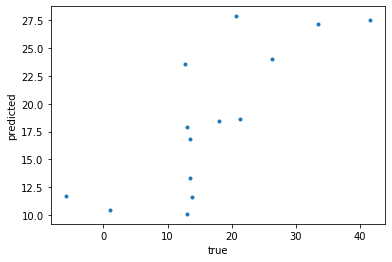

```python
# plot prediction and true
plt.plot(true, predicted, '.')
plt.xlabel("true")
plt.ylabel("predicted");
```